# Informe_proyecto

2023-05-06

# 1 **Introducción**

El Análisis de la relación entre las asesorías con respecto al estrés y el rendimiento académico es de suma importancia para reconocer factores en los que se vea involucrados el estrés en la vida universitaria, por tal motivo nuestro objetivo principal es analizar la relación de las asesorías con el estrés académico y la dificultad de un curso ocasionado durante la asignatura en los estudiantes UTEC en el periodo 2022-II. Para ello será necesario los siguientes objetivos específicos:

Para lograrlo, nos basamos en las respuestas proporcionadas por los alumnos de la universidad quienes nos ofrecieron una visión detallada de sus experiencias y percepciones.

Después de llevar a cabo una limpieza de datos exhaustiva en nuestro conjunto de datos, procedimos a realizar un análisis univariado de las variables más representativas de nuestro estudio. Esto nos permitió examinar y comprender mejor cada variable individualmente, identificando patrones y tendencias significativas.

Además, realizamos un análisis bivariado para explorar las relaciones entre las variables y responder a nuestros objetivos de investigación. Este análisis nos permitió examinar cómo se relacionan las asesorías, el estrés y el rendimiento académico entre sí, y cómo estas relaciones pueden influir en el desempeño general de los alumnos.

A través de este estudio, buscamos obtener una comprensión más profunda de cómo las asesorías, el estrés y el rendimiento académico se relacionan entre sí en el contexto de la UTEC.

# 2 **Relevancia**

> Estudiar la relación de las asesorías con el estrés y con el rendimiento académico de los alumnos de UTEC en periodo 2022-2 es sumamente relevante, ya que como estudiantes podemos conocer los desafíos y presiones que pueden causar las distintas asignaturas en nuestra vida diaria. Es cierto que el estrés puede afectar nuestra salud mental y/o física, así como nuestra capacidad para concentrarnos y aprender de manera eficiente. Por ello, el estudiar está problemática nos perimtiirá encontrar formas de apoyar y promover el bienestar de los estudiantes, como también encontrar los factores que lo generan, para así implementar estrategias del manejo de estrés, mejorando los recursos de apoyo creando entornos educativos más saludables y equilibrados.

# 3 Gráfico de Gant

[figure not shown]

# 4 **Datos**

## 4.1 **Recolección de datos**

> Para llevar a cabo la investigación del proyecto se realizo una encuesta en google form [Link de Encuesta](https://forms.gle/RmSSpXSrw85BEXQW7) para la adquisición de datos que nos permitarán analizar y obtener conclusiones a los distintos objetivos planteados.La encuesta se compartió por medio de enlaces a distintos grupos de whatsapp y telegram; para así minimizar sesgos que pudisen ocurrir. La encuesta consta de 4 secciones y 21 preguntas en donde se empezó con una introducción sobre el proyecto a desarrollar. Con el fin de obtener datos personales las encuestas fueron realizadas en el anonimato.

## 4.2 **Población, muestra y muestreo**

> La *población* donde se realizará la investigación son los alumnos de la Universidad de Ingeniería y Tecnología de las diferentes carreras del período 2022-2.

> La *unidad muestral* es un alumno Utec de las distintas carreras del período 2022-2.

> El *tamaño* de la muestra es de *204* alumnos, asimimsmo se realizó un *muestreo* aleatorio simple.

## 4.3 **Variables**

- CUANTITATIVAS:
  - Continuas:
    - Promedio ponderado

      > Los valores se limitaron en un intervalo de 0 a 20, además de usar el punto como separador decimal.
    - Tiempo de llegar a la universidad

      > En el cuestionario se pedirá los valores de recorrido en minutos pero para el estudio se realizará en horas, asimismo no se limitó los valores puesto que nos servirá para el analisis y dar respuestas a nuestros objetivos.
    - Valor de estrés

      > Con el fin de **no** realizar una doble encuesta nos ayudaremos de la prueba **SISCO SV**, el cual se basa de un estudio que estandariza las encuestas creadas con el fin de medir el estrés de los alumnos a través de 8 ítems. Por ello en nuestra investigación se usarán 7 ítems seleccionados, importantes para dar respuestas a nuestro estudio. En conjunto se usó la escala de Likert.
  - Discretas:
    - Cantidad de créditos matriculados

      > Se limitó a números enteros de 4 a 26.
    - Edad

      > Se limitó a responder con un valor numérico entero.
    - Tiempo predestinado a las asesoría

      > Se limitó a valores numéricos enteros, en intervalos de 0 a 16
    - Cuanto tiempo al ocio

      > Se limitó a valores numéricos enteros, en intervalos de 0 a 16. Cabe aclarar que en la recolección hace referencia a horas semanales.
- CUALITATIVAS:
  - Nominal:
    - carrera

      > Se restringió a las carreras actuales presentes en UTEC.
    - momentos de mayor estrés durante el ciclo

      > Se proporcionó 4 alternativas que englobarán interesés comunes para los encuestados
  - Jerárquica:
    - Satisfacción al término de las asignaturas

      > Sólo se podía ingresar entre opciones como “Frustrado, pude hacerlo mejor”,“Satisfecho, las asesorias me salvaron” y “Descontento, no conseguí resultados”.
    - Nivel de asistencia en las asesorías

      > Sólo se podía ingresar entre las opciones “Sí” y “No”.Dependiendo de ello respondería 3 preguntas relacionadas a las asesorías.
    - Satisfacción al término del uso de los espacios recreativos

      > Se proporcionó 4 alternativas que hacian referencia a una escala de satisfacción
    - ciclo

      > Se dió opciones desde “I Ciclo” hasta “X Ciclo”, que son las disponibles en cada carrera de UTEC.

## 4.4 **LIMPIEZA DE DATOS**

### 4.4.1 Librerías necesarias para la limpieza de datos

```r
library("readr")
library("dplyr")
library("modeest")
library("PerformanceAnalytics")
library("knitr")
```

### 4.4.2 Lectura y carga de datos en RSTUDIO

```r
DF1 <- read_csv("proyecto_datos.csv",col_types = "ccccnnncnnccnnnnnnncncc")
DF <- DF1
```

### 4.4.3 Nombres de las variables

*Antes de realizar cualquier acción, visualizaremos las variables que presentamos y su tipo, de esa manera confirmaremos que se hallan ingresado correctamente*

```r
names(DF)
```

```
##  [1] "v"
##  [2] "vr"
##  [3] "¿De qué carrera eres?"
##  [4] "¿En qué ciclo te encontrabas cursando el período 2022-II?"
##  [5] "Coméntanos, ¿Qué promedio obtuviste al finalizar el periodo 2022-II? \n(Responder numéricamente y con el punto como separador decimal)"
##  [6] "¿Cuál fue tú  edad\n en el año 2022?"
##  [7] "¿Cuánto tiempo dedicas a \nactividades de ocio?\n(Responder el tiempo \nmedido en horas)"
##  [8] "¿Cómo te sientes después \nde haber usado los espacios \nrecreativos en la Utec?"
##  [9] "Tomando tu hogar como referencia de punto de partida, ¿Cuánto tiempo te toma llegar a “UTEC”? \n(Tiempo medido en minutos)"
## [10] "Tomando en cuenta el ciclo 2022-2, ¿A cuántos créditos te llegaste a matricular?"
## [11] "¿Cuánto tiempo consideras que descansas durante el desarrollo del ciclo? (Tiempo medido en horas promedio de un día)"
## [12] "¿En qué momento consideras que sufres más estrés durante el desarrollo del ciclo?"
## [13] "Competencia de los compañeros del grupo"
## [14] "Sobrecarga de tareas y trabajos."
## [15] "La personalidad y el carácter del profesor."
## [16] "Las evaluaciones de los profesores (exámenes, ensayos, trabajos de investigación, etc.)"
## [17] "El tipo de trabajo que te piden los profesores (consulta de temas, fichas de trabajo, ensayos, mapas conceptuales, etc.)."
## [18] "Tiempo limitado para hacer el trabajo"
## [19] "No entender los temas que se abordan en la clase."
## [20] "¿Participaste en alguna de las asesorías brindadas en el periodo 2022-II?"
## [21] "¿Cuántas horas a la semana dedicabas a las asesorías?\n(escribe un número entero)"
## [22] "¿La ayuda recibida por parte de las asesorías ayudó a mitigar el nivel de estrés y ansiedad que presentaste?"
## [23] "Teniendo en cuenta la ayuda de las asesorías, ¿cómo te sentiste al término de las asignaturas?"
## [24] "Ingrese su número de celular para que participes en el sorteo"
## [25] "NIVEL DE ESTRES"
```

[output not shown]

*Se eliminaron correctamente, es por ello que podemos continuar con nuestra limpieza de datos.*

*Para facilitar el proceso de limpieza de datos, cambiaremos el nombres de nuestras variables, con fines prácticos*

```r
DF %>% rename(Carrera = "¿De qué carrera eres?"
              , Ciclo = "¿En qué ciclo te encontrabas cursando el período 2022-II?"
              , Promedio = "Coméntanos, ¿Qué promedio obtuviste al finalizar el periodo 2022-II? \n(Responder numéricamente y con el punto como separador decimal)"
              , Edad = "¿Cuál fue tú  edad\n en el año 2022?"
              , Ocio = "¿Cuánto tiempo dedicas a \nactividades de ocio?\n(Responder el tiempo \nmedido en horas)"
              , Transporte = "Tomando tu hogar como referencia de punto de partida, ¿Cuánto tiempo te toma llegar a “UTEC”? \n(Tiempo medido en minutos)"
              , Creditos = "Tomando en cuenta el ciclo 2022-2, ¿A cuántos créditos te llegaste a matricular?"
              , Tiempo_libre = "¿Cuánto tiempo consideras que descansas durante el desarrollo del ciclo? (Tiempo medido en horas promedio de un día)"
              , Nivel_estres  = "¿En qué momento consideras que sufres más estrés durante el desarrollo del ciclo?"
              , Recreativos = "¿Cómo te sientes después \nde haber usado los espacios \nrecreativos en la Utec?"
              , Competencia = "Competencia de los compañeros del grupo"
              , Sobrecarga = "Sobrecarga de tareas y trabajos."
              , Caracter_profesor = "La personalidad y el carácter del profesor."
              , Evaluaciones = "Las evaluaciones de los profesores (exámenes, ensayos, trabajos de investigación, etc.)"
              , Trabajo_profesores = "El tipo de trabajo que te piden los profesores (consulta de temas, fichas de trabajo, ensayos, mapas conceptuales, etc.)."
              , Tiempo_limitado = "Tiempo limitado para hacer el trabajo"
              , No_entender_temas = "No entender los temas que se abordan en la clase."
              , Asesorias = "¿Participaste en alguna de las asesorías brindadas en el periodo 2022-II?"
              , Horas_asesorias = "¿Cuántas horas a la semana dedicabas a las asesorías?\n(escribe un número entero)"
              , Ayuda_asesorias = "¿La ayuda recibida por parte de las asesorías ayudó a mitigar el nivel de estrés y ansiedad que presentaste?"
              , Satisfaccion_asesorias = "Teniendo en cuenta la ayuda de las asesorías, ¿cómo te sentiste al término de las asignaturas?"
              ) ->DF
```

*El nombre de las variables se han cambiado correctamente.*

### 4.4.4 Limpieza de datos

*Iniciaremos visualizando si existe algún problema con nuestra base de datos, para ello emplearemos el comando problems()*.

```
## [1] "La cantidad de problemas en el estudio es: 0"
```

*Seguido de ello, comprobaremos si existe datos faltantes en nuestra base de datos*

```
## [1] "La cantidad de datos faltantes es: 117"
```

*Presentamos 117 datos faltantes, analizaremos su procedencia, para lo cual emplearemos el siguiente comando, donde podremos visualizar cuántos datos faltantes hay por variable*

```r
colSums(is.na(DF))
```

```
##                Carrera                  Ciclo               Promedio
##                      0                      0                      0
##                   Edad                   Ocio            Recreativos
##                      0                      0                      0
##             Transporte               Creditos           Tiempo_libre
##                      0                      0                      0
##           Nivel_estres            Competencia             Sobrecarga
##                      0                      0                      0
##      Caracter_profesor           Evaluaciones     Trabajo_profesores
##                      0                      0                      0
##        Tiempo_limitado      No_entender_temas              Asesorias
##                      0                      0                      0
##        Horas_asesorias        Ayuda_asesorias Satisfaccion_asesorias
##                     39                     39                     39
```

*Podemos ver que sólo se presentan datos faltantes en 3 variables, para observar por qué procede visualizaremos las filas correspondientes a éstos datos faltantes*

```r
DF %>% group_by(Asesorias=(Asesorias)) %>% select(Horas_asesorias,Satisfaccion_asesorias)
```

```
## # A tibble: 204 x 3
## # Groups:   Asesorias [2]
##    Asesorias Horas_asesorias Satisfaccion_asesorias
##    <chr>               <dbl> <chr>
##  1 Si                      1 Descontento, no consegui resultados
##  2 Si                      2 Descontento, no consegui resultados
##  3 Si                      4 Satisfecho, las asesorias me salvaron
##  4 Si                      8 Satisfecho, las asesorias me salvaron
##  5 Si                      4 Frustrado, pude hacerlo mejor
##  6 Si                      4 Satisfecho, las asesorias me salvaron
##  7 Si                      4 Frustrado, pude hacerlo mejor
##  8 No                     NA <NA>
##  9 No                     NA <NA>
## 10 Si                      4 Frustrado, pude hacerlo mejor
## # i 194 more rows
```

*Tal como se sospechaba, estos NA corresponden a las 39 personas que seleccionaron la opción “No” en la variable asesoría, ante ello y tomando en cuenta que no asistieron a las asesorías, podemos concluir que:*

- *La cantidad de horas de los que no asistieron a las asesorías sera igual a 0.*
- *Para las variables “Ayuda_asesorias” y “Satisfacion_asesorias”, se creará una opción llamada “No asistí a asesorías”, que englobaría las respuestas de este grupo de encuestados.*

*Implementaremos estos cambios, utilizando comandos de Rstudio*

```r
DF %>% mutate( Horas_asesorias =
              ifelse(Asesorias == 'No', 0, Horas_asesorias))  -> DF
DF %>% mutate( Ayuda_asesorias =
              ifelse(Asesorias == 'No', 'No asistí a asesorías', Ayuda_asesorias))  -> DF
DF %>% mutate( Satisfaccion_asesorias =
              ifelse(Asesorias == 'No', 'No asistí a asesorías', Satisfaccion_asesorias))  -> DF
```

*Comprobaremos si continúan existiendo NA en nuestra base de datos*

```
##                Carrera                  Ciclo               Promedio
##                      0                      0                      0
##                   Edad                   Ocio            Recreativos
##                      0                      0                      0
##             Transporte               Creditos           Tiempo_libre
##                      0                      0                      0
##           Nivel_estres            Competencia             Sobrecarga
##                      0                      0                      0
##      Caracter_profesor           Evaluaciones     Trabajo_profesores
##                      0                      0                      0
##        Tiempo_limitado      No_entender_temas              Asesorias
##                      0                      0                      0
##        Horas_asesorias        Ayuda_asesorias Satisfaccion_asesorias
##                      0                      0                      0
```

### 4.4.5 *Limpieza y analisis de cada variable*

#### 4.4.5.1 Variable “Carrera”

| Carrera | n |
| --- | --- |
| Administración y Negocios Digitales | 8 |
| Bioingenieria | 17 |
| Ciencia de Datos | 4 |
| Ciencias de la Computacion | 17 |
| Ing Ambiental | 23 |
| Ing Civil | 25 |
| Ing Electronica | 4 |
| Ing Industrial | 47 |
| Ing Mecanica | 10 |
| Ing Mecatronica | 29 |
| Ing Quimica | 14 |
| Ing de la Energia | 6 |

*No presenta inconvenientes, que requiera una limpieza de datos*

#### 4.4.5.2 Variable “Ciclo”

| Ciclo | n |
| --- | --- |
| I Ciclo | 48 |
| II Ciclo | 77 |
| III Ciclo | 34 |
| IV Ciclo | 24 |
| IX Ciclo | 1 |
| V Ciclo | 9 |
| VI Ciclo | 4 |
| VII Ciclo | 3 |
| VIII Ciclo | 1 |
| X Ciclo | 3 |

*No presenta inconvenientes, que requiera una limpieza de datos*

#### 4.4.5.3 Variable “Promedio”

*No presenta inconvenientes, que requiera una limpieza de datos*

#### 4.4.5.4 Variable “Edad”

*Se encontraron algunas irregularidades. Visualizaremos los datos atípicos*

| Carrera | Ciclo | Promedio | Edad | Ocio | Recreativos | Transporte | Creditos | Tiempo_libre | Nivel_estres | Competencia | Sobrecarga | Caracter_profesor | Evaluaciones | Trabajo_profesores | Tiempo_limitado | No_entender_temas | Asesorias | Horas_asesorias | Ayuda_asesorias | Satisfaccion_asesorias |
| --- | --- | --- | --- | --- | --- | --- | --- | --- | --- | --- | --- | --- | --- | --- | --- | --- | --- | --- | --- | --- |
| Ing Mecatronica | VIII Ciclo | 5.1 | 29 | 14 | Estresado porque pude haber avanzado proyectos | 360 | 26 | 1 | Todas las semanas me causan estrés por la cantidad de tareas | 1 | 5 | 1 | 1 | 1 | 1 | 1 | Si | 1 | Poco | Descontento, no consegui resultados |
| Ing Industrial | VI Ciclo | 12.8 | 28 | 3 | Estresado porque pude haber avanzado proyectos | 60 | 13 | 7 | Semana de examenes parciales | 3 | 3 | 3 | 3 | 3 | 4 | 3 | Si | 2 | Regular | Descontento, no consegui resultados |
| Ing de la Energia | I Ciclo | 10.5 | 26 | 8 | Estresado porque pude haber avanzado proyectos | 3 | 24 | 4 | Todas las semanas me causan estrés por la cantidad de tareas | 1 | 1 | 1 | 1 | 1 | 1 | 1 | Si | 6 | Muchisimo | Descontento, no consegui resultados |

| Carrera | Ciclo | Promedio | Edad | Ocio | Recreativos | Transporte | Creditos | Tiempo_libre | Nivel_estres | Competencia | Sobrecarga | Caracter_profesor | Evaluaciones | Trabajo_profesores | Tiempo_limitado | No_entender_temas | Asesorias | Horas_asesorias | Ayuda_asesorias | Satisfaccion_asesorias |
| --- | --- | --- | --- | --- | --- | --- | --- | --- | --- | --- | --- | --- | --- | --- | --- | --- | --- | --- | --- | --- |
| Ing Civil | V Ciclo | 11 | 15 | 200 | Estresado porque pude haber avanzado proyectos | 1000 | 8 | 1 | Semana de exámenes finales | 5 | 5 | 5 | 5 | 5 | 5 | 5 | Si | 8 | Poco | Frustrado, pude hacerlo mejor |
| Ciencias de la Computacion | X Ciclo | 4 | 9 | 50 | Enérgico capaz de todo | 180 | 21 | 8 | Todas las semanas me causan estrés por la cantidad de tareas | 1 | 1 | 1 | 1 | 3 | 3 | 1 | Si | 4 | Poco | Satisfecho, las asesorias me salvaron |

*Como la edad no concuerda con el ciclo presentado al momento de llenar la encuesta, procedemos a eliminar los casos atípicos, debido a que presentan incoherencias en otras variables*

```r
fila<-which(DF$Edad == 9)
DF<-DF[-fila,]
fila2<-which(DF$Edad == 15)
DF<-DF[-fila2,]
fila3<-which(DF$Edad == 29)
DF<-DF[-fila3,]
fila4<-which(DF$Edad == 28)
DF<-DF[-fila4,]
fila5<-which(DF$Edad == 26)
DF<-DF[-fila5,]
```

*Luego de realizar esto, tenemos edades que concuerden con el rango deseado al momento de realizar la encuesta*

#### 4.4.5.5 Variable “Ocio”

*Presenta datos atípicos, procedemos a realizar la limpieza de datos*

```r
DF %>% mutate(Ocio =
        ifelse(Ocio >= 10, median(DF$Ocio), Ocio)) -> DF
DF %>% mutate(Ocio =
        ifelse(Ocio == 0, median(DF$Ocio), Ocio)) -> DF
```

| Ocio | n |
| --- | --- |
| 1.0 | 12 |
| 1.5 | 1 |
| 2.0 | 41 |
| 2.5 | 2 |
| 3.0 | 36 |
| 4.0 | 62 |
| 5.0 | 17 |
| 6.0 | 14 |
| 7.0 | 3 |
| 8.0 | 10 |
| 9.0 | 1 |

#### 4.4.5.6 Variable “Transporte”

*Presenta datos atípicos, por ello reemplazaremos sus valores con la media de la variable*

*Seguido de ello, realizaremos la conversión de minutos a horas*

```r
aux1<- round((DF$Transporte/60),3)
DF$Transporte = aux1
```

| Transporte | n |
| --- | --- |
| 0.083 | 5 |
| 0.100 | 1 |
| 0.117 | 1 |
| 0.167 | 6 |
| 0.200 | 1 |
| 0.250 | 18 |
| 0.333 | 11 |
| 0.417 | 3 |
| 0.483 | 1 |
| 0.500 | 17 |

*Ahora ya no presenta inconvenientes, que requiera una limpieza de datos*

#### 4.4.5.7 Variable “Creditos”

```
## # A tibble: 18 x 2
##    Creditos     n
##       <dbl> <int>
##  1        4     1
##  2        5     1
##  3        6     2
##  4        7     7
##  5       10     1
##  6       12     1
##  7       14     2
##  8       15     4
##  9       16     9
## 10       17    14
## 11       18    14
## 12       19    13
## 13       20    65
## 14       21    28
## 15       22    23
## 16       23     7
## 17       24     4
## 18       26     3
```

*No presenta inconvenientes que requieran una limpieza de datos*

#### 4.4.5.8 Variable “Tiempo_libre”

*Presenta algunas irregularidades*

```r
DF$Tiempo_libre <- as.numeric(DF$Tiempo_libre)
DF %>% mutate(Tiempo_libre =
        ifelse(Tiempo_libre >= 10,median(DF$Tiempo_libre), Tiempo_libre))-> DF
kable(DF %>% count(Tiempo_libre))
```

| Tiempo_libre | n |
| --- | --- |
| 0 | 1 |
| 1 | 5 |
| 2 | 20 |
| 3 | 35 |
| 4 | 34 |
| 5 | 36 |
| 6 | 32 |
| 7 | 25 |
| 8 | 10 |
| 9 | 1 |

*Ya no presenta inconvenientes que requieran una limpieza de datos*

#### 4.4.5.9 Variable “Nivel_estres”

| Nivel_estres | n |
| --- | --- |
| Entrega de trabajos finales | 42 |
| Semana de examenes parciales | 33 |
| Semana de exámenes finales | 32 |
| Todas las semanas me causan estrés por la cantidad de tareas | 92 |

*No presenta inconvenientes que requiera una limpieza de datos*

#### 4.4.5.10 Variable “Recreativos”

| Recreativos | n |
| --- | --- |
| Con ideas claras para mis proyectos | 28 |
| Enérgico capaz de todo | 11 |
| Estresado porque pude haber avanzado proyectos | 80 |
| Feliz y relajado | 80 |

*No presenta inconvenientes que requieran una limpieza de datos*

#### 4.4.5.11 Variable “Asesorias”

| Asesorias | n |
| --- | --- |
| No | 39 |
| Si | 160 |

*No presenta inconvenientes que requieran una limpieza de datos*

#### 4.4.5.12 Variable “Horas_asesorias”

```r
DF %>% mutate(Horas_asesorias =
        ifelse(Horas_asesorias == 16 ,median(DF$Horas_asesorias), Horas_asesorias))-> DF
```

```r
kable(DF %>% count(Horas_asesorias))
```

| Horas_asesorias | n |
| --- | --- |
| 0 | 40 |
| 1 | 5 |
| 2 | 35 |
| 3 | 14 |
| 4 | 75 |
| 5 | 5 |
| 6 | 19 |
| 7 | 2 |
| 8 | 2 |
| 10 | 2 |

*No presenta inconvenientes que requieran una limpieza de datos*

#### 4.4.5.13 Variable “Ayuda_asesorias”

```r
kable(DF %>% count(Ayuda_asesorias))
```

| Ayuda_asesorias | n |
| --- | --- |
| Muchisimo | 22 |
| No asistí a asesorías | 39 |
| Poco | 44 |
| Regular | 94 |

*No presenta inconvenientes que requieran una limpieza de datos*

#### 4.4.5.14 Variable “Satisfaccion_asesorias”

```r
kable(DF %>% count(Satisfaccion_asesorias))
```

| Satisfaccion_asesorias | n |
| --- | --- |
| Descontento, no consegui resultados | 13 |
| Frustrado, pude hacerlo mejor | 81 |
| No asistí a asesorías | 39 |
| Satisfecho, las asesorias me salvaron | 66 |

*No presenta inconvenientes que requieran una limpieza de datos*

## 4.5 **Creación de una nueva variable necesaria para nuestro estudio**

```r
BaseDatosLimpio<- DF
DF$Valor_estres=""
DF$Valor_estres<-as.numeric(DF$Valor_estres)
DF %>% mutate(Valor_estres =
        ifelse(is.na(Valor_estres) == TRUE ,Competencia + Sobrecarga + Caracter_profesor + Evaluaciones + Trabajo_profesores + Tiempo_limitado + No_entender_temas)/35, Valor_estres)-> DF
```

| Valor_estrés | Cantidad |
| --- | --- |
| 0.2000000 | 2 |
| 0.3714286 | 3 |
| 0.4000000 | 2 |
| 0.4285714 | 2 |
| 0.4571429 | 4 |
| 0.4857143 | 2 |
| 0.5142857 | 4 |
| 0.5428571 | 6 |
| 0.5714286 | 9 |
| 0.6000000 | 11 |

# 5 **Análisis descriptivo**

## 5.1 **Análisis univariado**

### 5.1.1 *Librerías necesarias*

```r
library("readr")
library("dplyr")
library("EnvStats")
library("modeest")
library("janitor")
library("plotrix")
library("knitr")
```

### 5.1.2 VARIABLES CUANTITATIVAS

> Se realizará comentarios en las variables relevantes en el estudio, del mismo modo se presentarán gráficas y sus descriptores numéricos respectivos en todas las variables mencionadas en el estudio.

#### 5.1.2.1 Variable “PROMEDIO”

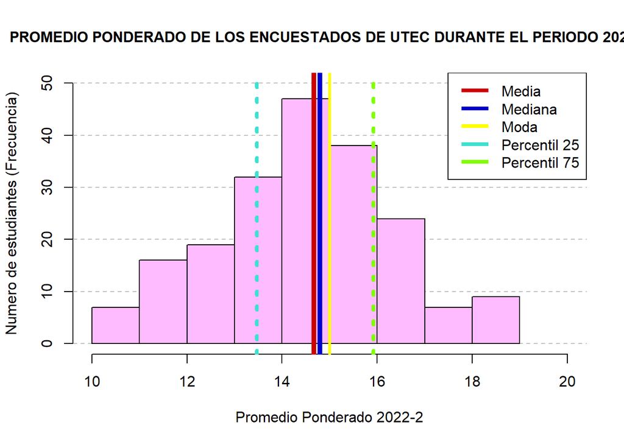

| Variable | Tamaño | Min | Max | Media | Moda | Mediana | Varianza | Des_EST | Dif_Rango | Rang_IntQ | Coef_disp |
| --- | --- | --- | --- | --- | --- | --- | --- | --- | --- | --- | --- |
| Promedio | 199 | 10.9 | 19 | 14.67 | 15 | 14.8 | 3.43 | 1.85 | 8.1 | 2.45 | 0.13 |

> En el estudio que estamos realizando a los alumnos de UTEC en el periodo 2022-2, el rango de promedios que presenta los alumnos oscilan entre 10.9 y 19, presentando como la mayor frecuencia absoluta los alumnos que tienen notas entre 14 y 15 siendo 47 de ellos. En cambio la menor frecuencia absoluta se halla en los alumnos que sacaron como promedio ponderado de 10.9 a 11 y los alumnos que tienen de ponderado de 17 a 18, presentando como promedio ponderado de los alumnos es de 14.67 y de mediana 14.8. Mediante la gráfica obtenida podemos apreciar que no existe una considerable variación ya que la mediana y la media se aproximan en su valor (media ≈ mediana), por lo que podemos decir que es una gráfica simétrica y que los datos están en centrados en los ponderados de 13 y 17 de los alumnos de UTEC en el periodo 2022-2.

#### 5.1.2.2 Variable “VALOR DE ESTRÉS”

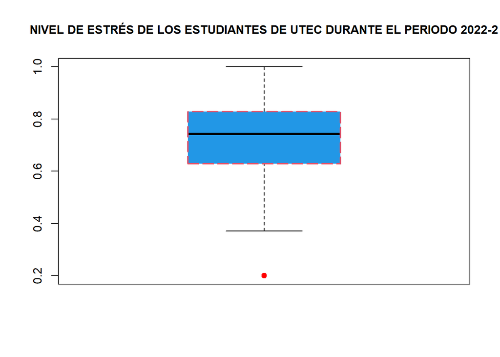

| Variable | Tamaño | Min | Max | Media | Moda | Mediana | Varianza | Des_EST | Dif_Rango | Rang_IntQ | Coef_disp |
| --- | --- | --- | --- | --- | --- | --- | --- | --- | --- | --- | --- |
| Valor_estres | 199 | 0.2 | 1 | 0.72 | 0.83 | 0.74 | 0.02 | 0.15 | 0.8 | 0.2 | 0.21 |

En el estudio que estamos realizando a los alumnos de UTEC en el periodo 2022-2, ésta es la variable más importante de nuestro estudio, nos brindará información para nuestros objetivos, la gráfica nos brinda información de esta variable como que existen valores que oscilan entre los valores de 0 y 1. El promedio de los valores de estrés obtenido es de 0.72 siendo una cifra preocupante, más adelante será explicado detalladamente que significa cada valor obtenido en el estudio. Se obtuvo que la gran mayoría sintieron un nivel de estrés entre 0.4 y 1 en periodo 2022-2 sin embargo por lo menos hubo un estudiante que ha experimentado un nivel de estrés bajo de 0.2 siendo un valor atípico.

Por otro lado, en la gráfica se puede visualizar la presencia de datos mínimos, lo cual es un resultado completamente normal y esperado en este tipo de estudios, pero resulta interesante analizar si existe alguna correlación entre éstas, es por ello que, se realizará la siguiente tabla con los datos más resaltantes de cada una, lo cual nos servirá para realizar conclusiones, si es que lo amerita.

| Carrera | Ciclo | Promedio | Ocio | Transporte | Creditos | Tiempo_libre | Asesorias | Horas_asesorias | Satisfaccion_asesorias | Valor_estres |
| --- | --- | --- | --- | --- | --- | --- | --- | --- | --- | --- |
| Administración y Negocios Digitales | X Ciclo | 19 | 4 | 3.0 | 12 | 3 | Si | 7 | Descontento, no consegui resultados | 0.2 |
| Ing Industrial | X Ciclo | 11 | 8 | 1.5 | 18 | 8 | No | 0 | No asistí a asesorías | 0.2 |

*Aparentemente a pesar de tener similitudes en lo que respecta al Ciclo y al nivel de estrés que presentan, la conclusión a leves rasgos que podemos hacer, es que a pesar de tener contextos sumamente diferentes (se puede concluir ello debido a la clara diferencia en diversos respuestas presentados por los estudiantes en la encuesta) ambos pueden llegar a poseer un nivel de estrés relativamente bajo.*

#### 5.1.2.3 Variable “EDAD”

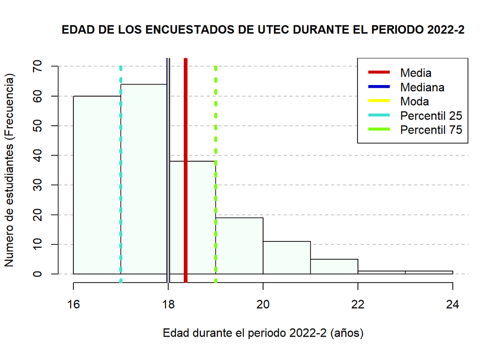

| Variable | Tamaño | Min | Max | Media | Moda | Mediana | Varianza | Des_EST | Dif_Rango | Rang_IntQ | Coef_disp |
| --- | --- | --- | --- | --- | --- | --- | --- | --- | --- | --- | --- |
| Edad | 199 | 16 | 24 | 18.37 | 18 | 18 | 2.04 | 1.43 | 8 | 2 | 0.08 |

#### 5.1.2.4 Variable “OCIO”

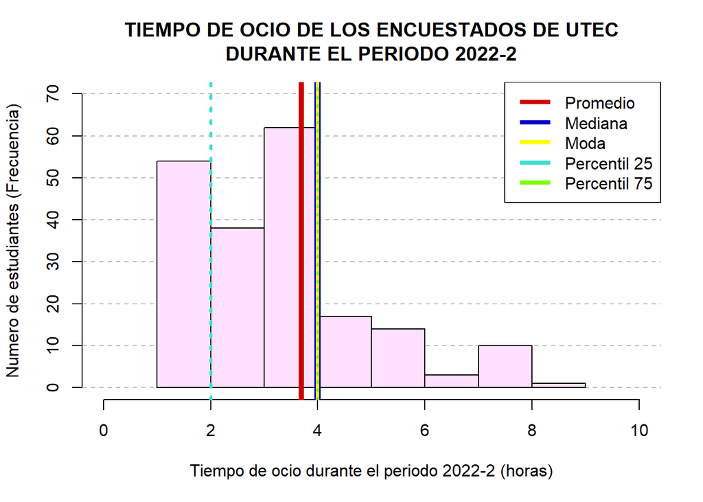

| Variable | Tamaño | Min | Max | Media | Moda | Mediana | Varianza | Des_EST | Dif_Rango | Rang_IntQ | Coef_disp |
| --- | --- | --- | --- | --- | --- | --- | --- | --- | --- | --- | --- |
| Ocio | 199 | 1 | 9 | 3.7 | 4 | 4 | 2.96 | 1.72 | 8 | 2 | 0.47 |

#### 5.1.2.5 Variable “TRANSPORTE”

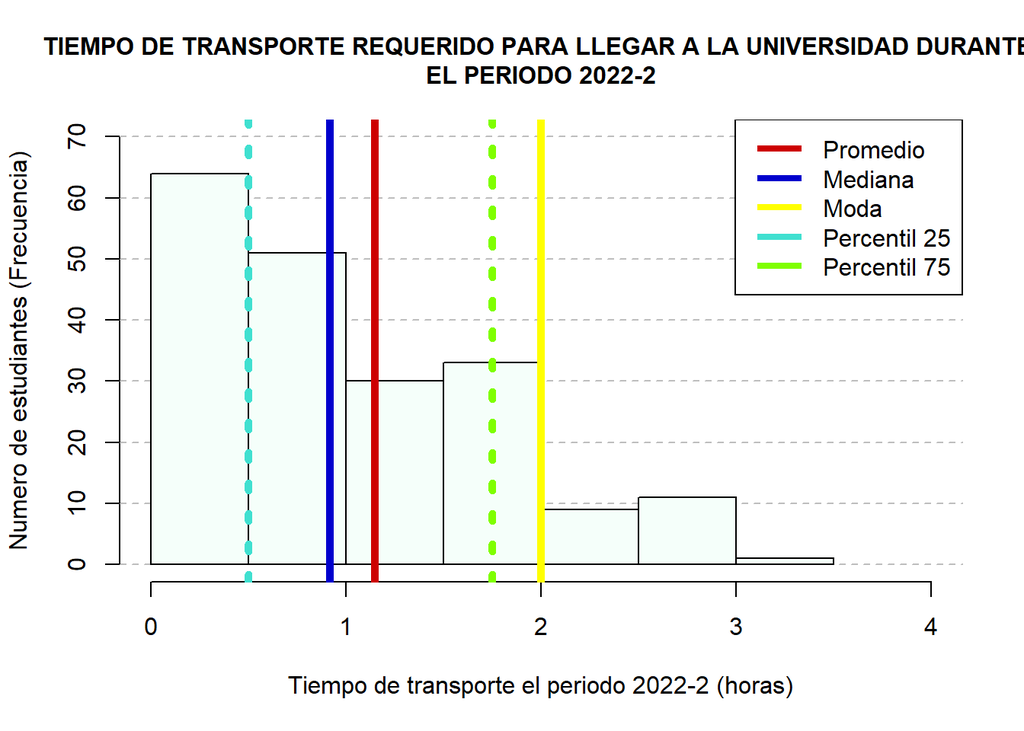

| Variable | Tamaño | Min | Max | Media | Moda | Mediana | Varianza | Des_EST | Dif_Rango | Rang_IntQ | Coef_disp |
| --- | --- | --- | --- | --- | --- | --- | --- | --- | --- | --- | --- |
| Transporte | 199 | 0.083 | 3.167 | 1.15 | 2 | 0.92 | 0.65 | 0.81 | 3.084 | 1.25 | 0.7 |

#### 5.1.2.6 Variable “TIEMPO LIBRE”

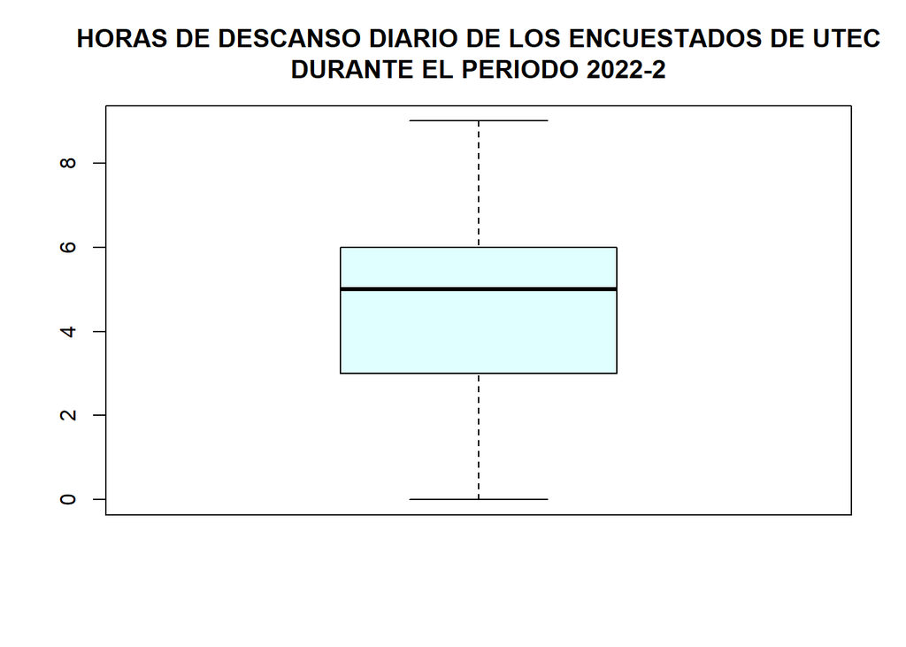

| Variable | Tamaño | Min | Max | Media | Moda | Mediana | Varianza | Des_EST | Dif_Rango | Rang_IntQ | Coef_disp |
| --- | --- | --- | --- | --- | --- | --- | --- | --- | --- | --- | --- |
| Tiempo_libre | 199 | 0 | 9 | 4.63 | 5 | 5 | 3.38 | 1.84 | 9 | 3 | 0.4 |

#### 5.1.2.7 Variable “HORAS ASESORIAS”

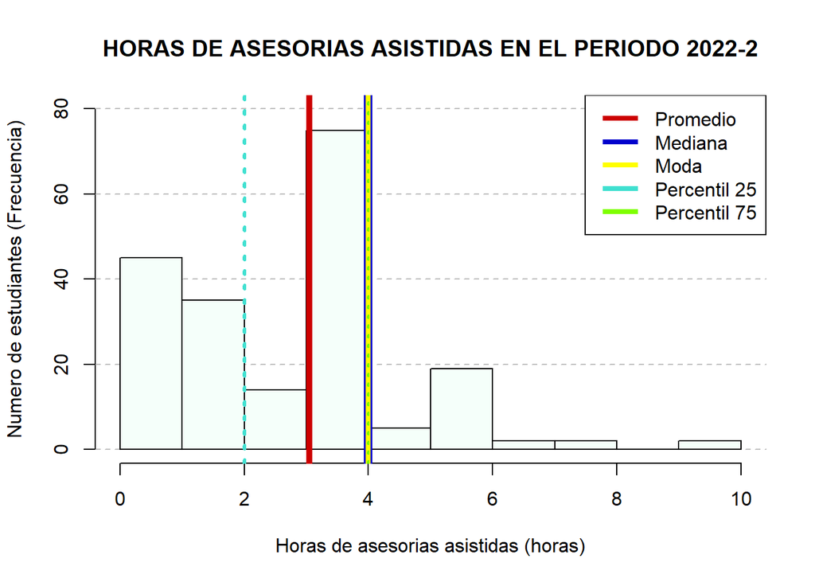

| Variable | Tamaño | Min | Max | Media | Moda | Mediana | Varianza | Des_EST | Dif_Rango | Rang_IntQ | Coef_disp |
| --- | --- | --- | --- | --- | --- | --- | --- | --- | --- | --- | --- |
| Horas_asesorias | 199 | 0 | 10 | 3.05 | 4 | 4 | 4.35 | 2.08 | 10 | 2 | 0.68 |

#### 5.1.2.8 Variable “CRÉDITOS”

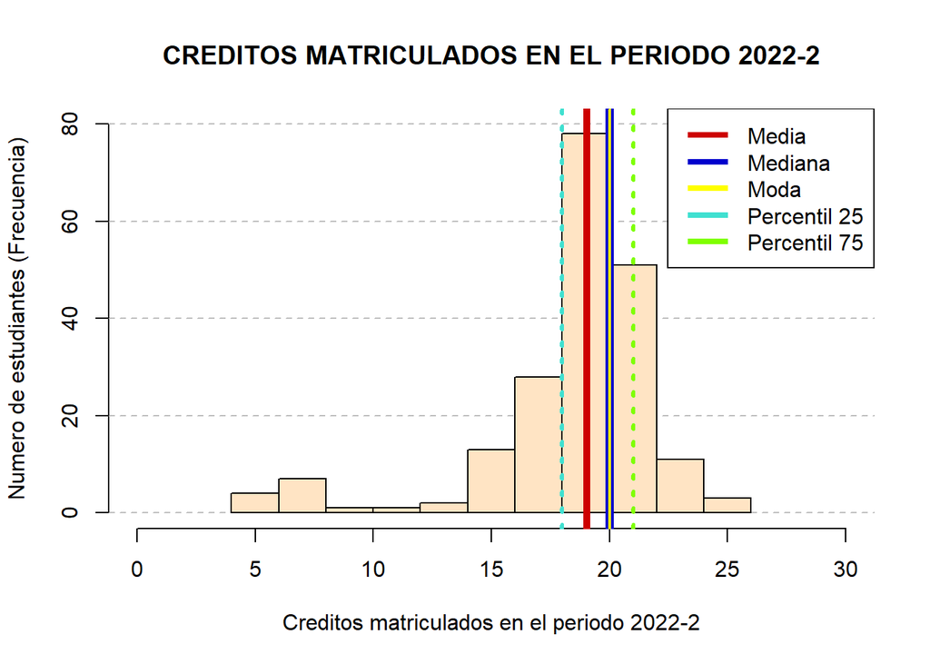

| Variable | Tamaño | Min | Max | Media | Moda | Mediana | Varianza | Des_EST | Dif_Rango | Rang_IntQ | Coef_disp |
| --- | --- | --- | --- | --- | --- | --- | --- | --- | --- | --- | --- |
| Creditos | 199 | 4 | 26 | 19.05 | 20 | 20 | 14.67 | 3.83 | 22 | 3 | 0.2 |

### 5.1.3 VARIABLES CUALITATIVAS

> Del mismo modo realizaremos análisis de las variables cualitativas, comentando conclusiones en aquellas que son más relevantes para el estudio.

#### 5.1.3.1 Variable “SATISFACCIÓN ASESORIAS”

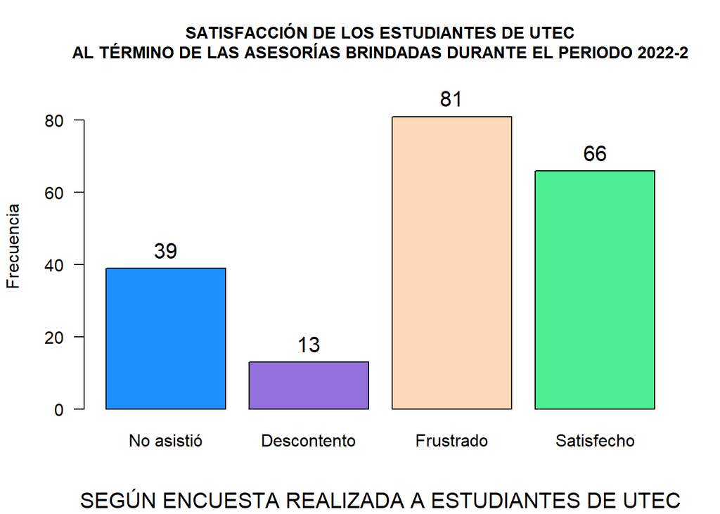

```
## [1] "No asistí a asesorías"
```

#### 5.1.3.2 Variable “ASESORIAS”

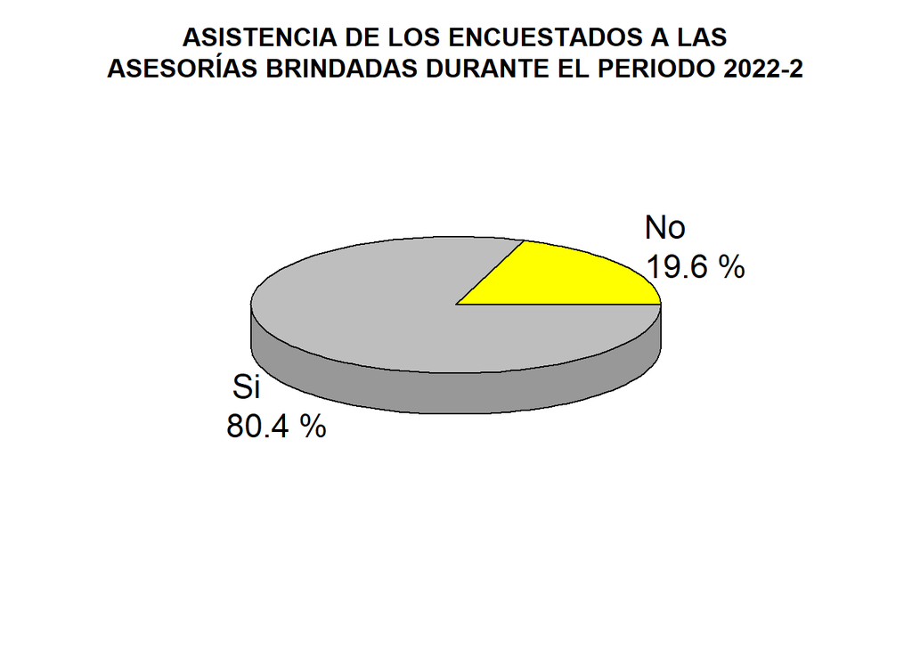

| Respuestas | Cantidad | Porcentaje |
| --- | --- | --- |
| NO | 39 | 19.6 |
| SÍ | 160 | 80.4 |

```
## [1] "El caso con mayor repeteciones en la variable es Si"
```

```
## [1] "El valor central de la varibale es Si"
```

#### 5.1.3.3 Variable “CARRERA”

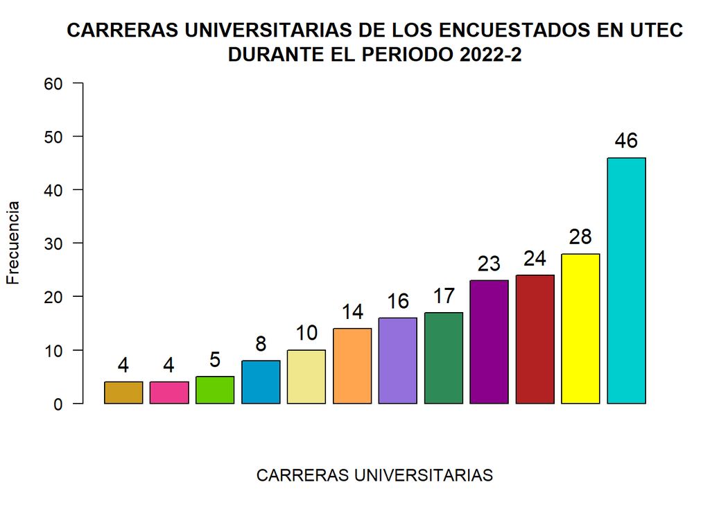

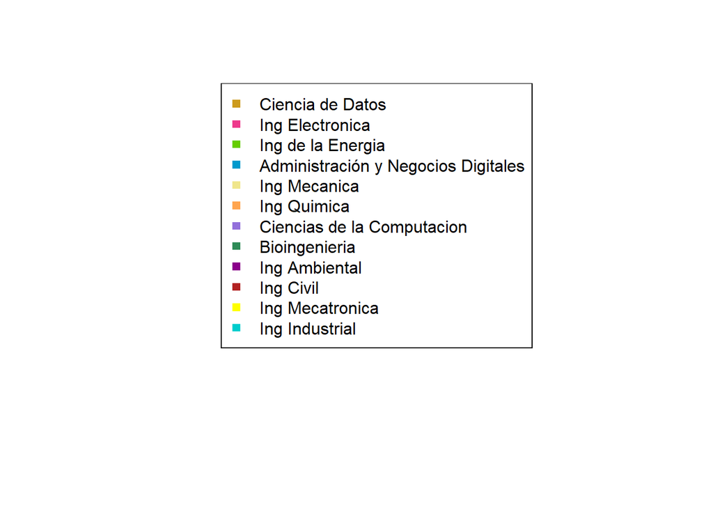

| Carreras | Cantidad |
| --- | --- |
| Ciencia de Datos | 4 |
| Ing Electronica | 4 |
| Ing de la Energia | 5 |
| Administración y Negocios Digitales | 8 |
| Ing Mecanica | 10 |
| Ing Quimica | 14 |
| Ciencias de la Computacion | 16 |
| Bioingenieria | 17 |
| Ing Ambiental | 23 |
| Ing Civil | 24 |
| Ing Mecatronica | 28 |
| Ing Industrial | 46 |

```
## [1] "La carrera con mayor repeteciones en el estudio esIng Industrial"
```

```
## [1] "El porcentaje de las personas que estudian Ing Industrial es:  23.12 %"
```

```
## [1] "La mediana del estudio es la carrera Ing Electronica"
```

#### 5.1.3.4 Variable “NIVEL ESTRES”

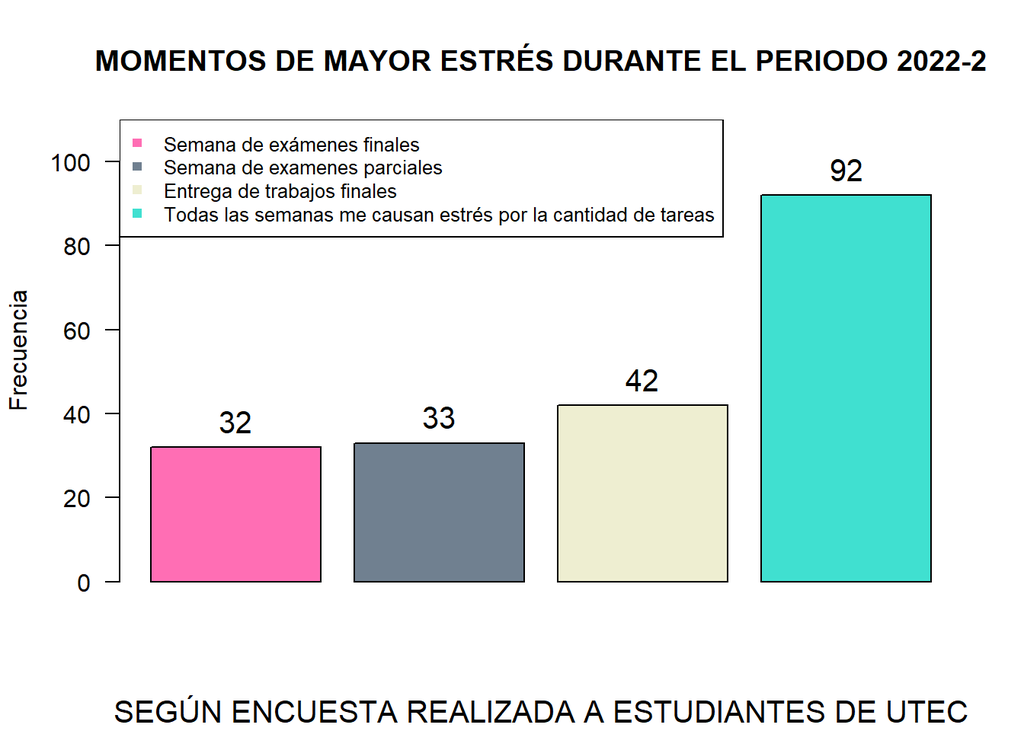

| Momentos_estres | Freceuncia |
| --- | --- |
| Semana de exámenes finales | 32 |
| Semana de examenes parciales | 33 |
| Entrega de trabajos finales | 42 |
| Todas las semanas me causan estrés por la cantidad de tareas | 92 |

```
## [1] "El porcentaje de las personas que sienten estrés todas las semanas son el:  46.23 %"
```

En el estudio realizado, recopilamos datos que nos fueron de mucha ayuda al momento de determinar en qué momento del ciclo los alumnos de UTEC presentan estrés en el periodo 2022-2, para lo cual otorgamos a cada encuestado a opción de responder entre cuatro alternativas que representan los momentos de mayor estrés durante el ciclo las cuales eran: semana de exámenes finales, semana de exámenes finales, entrega de trabajos finales o todas las semanas me causan estrés por la cantidad de tareas. Se puede concluir que los alumnos de UTEC durante el periodo 2022-2 sintieron en su mayoría mayor estrés todas las semanas por la cantidad de tareas, representando el 46.23 % de los datos recolectados.

#### 5.1.3.5 Variable “CICLO”

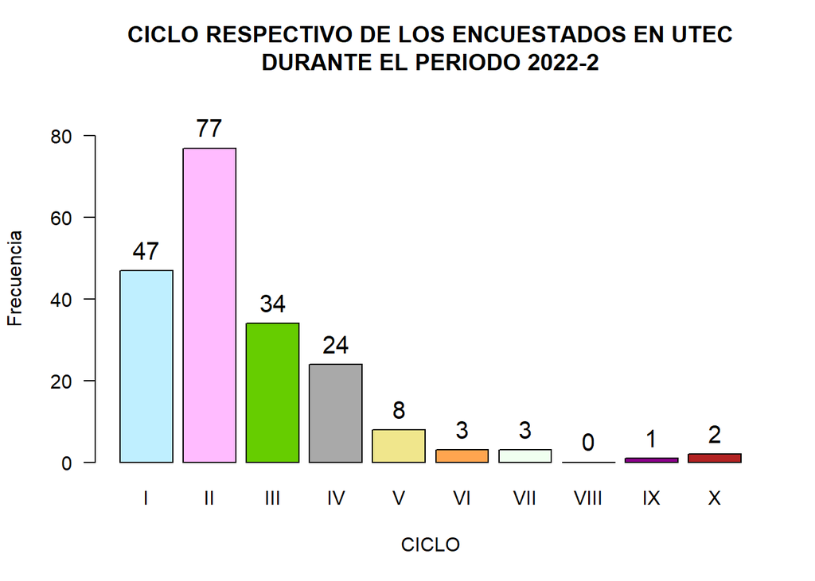

```
## [1] "El caso con mayor repeticones en la variable ciclo es II Ciclo"
```

```
## [1] "El 50% de los datos se encunetran por encima y por debajo de II Ciclo"
```

#### 5.1.3.6 Variable “AYUDA ASESORIAS”

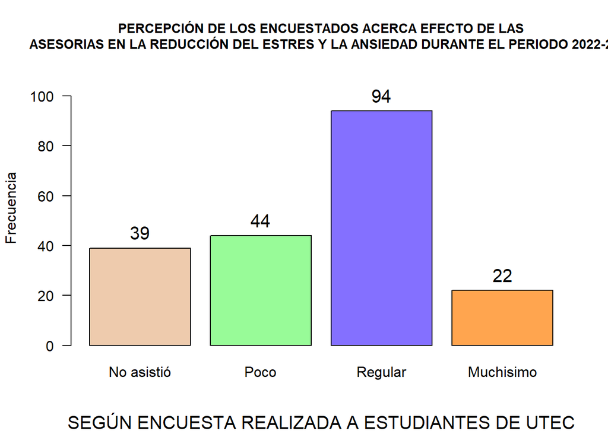

```
## [1] "El caso con mayor repeticones sobre la participación en las asesorías es Regular"
```

```
## [1] "El 50% de los datos se encunetran por encima y por debajo de la respuesta  Poco"
```

#### 5.1.3.7 Variable “RECREATIVOS”

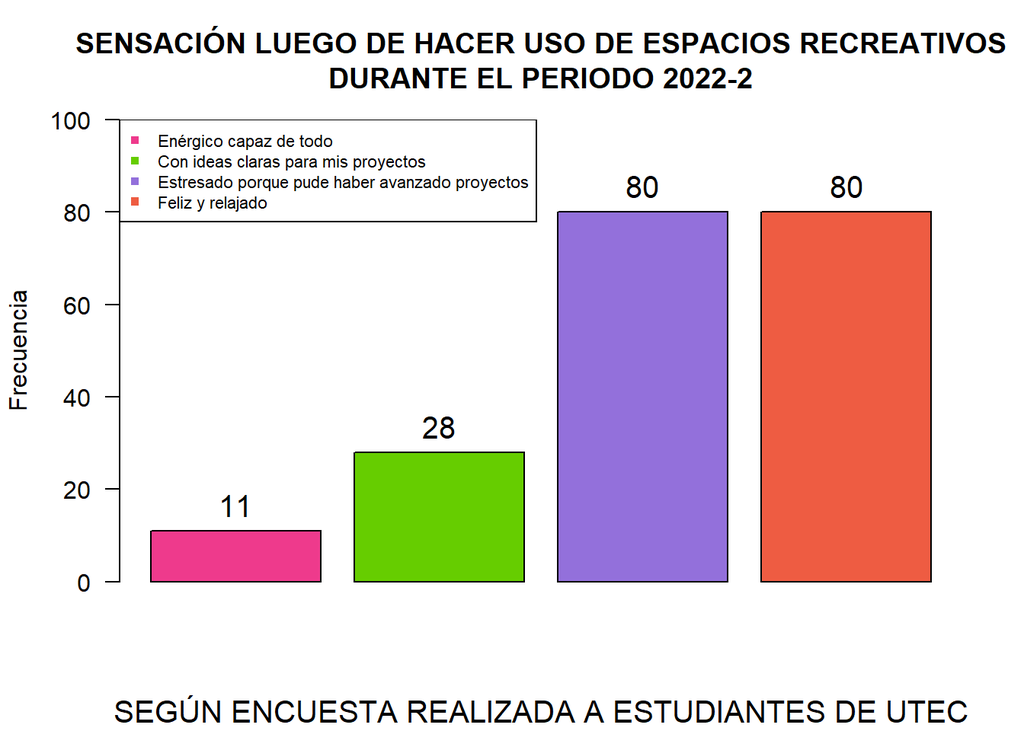

```
## [1] "El caso con mayor repeticones sobre la participación en espacios recreativos es Estresado porque pude haber avanzado proyectos"
```

```
## [1] "El 50% de los datos se encunetran por encima y por debajo de la respuesta  Estresado porque pude haber avanzado proyectos"
```

## 5.2 Análisis descriptivo *Bivariado*

### 5.2.1 OBJETIVO PRINCIPAL:

> “Analizar la relación de las asesorías con el estrés académico y la dificultad de un curso ocasionado durante la asignatura en los estudiantes UTEC en el periodo 2022-2.”

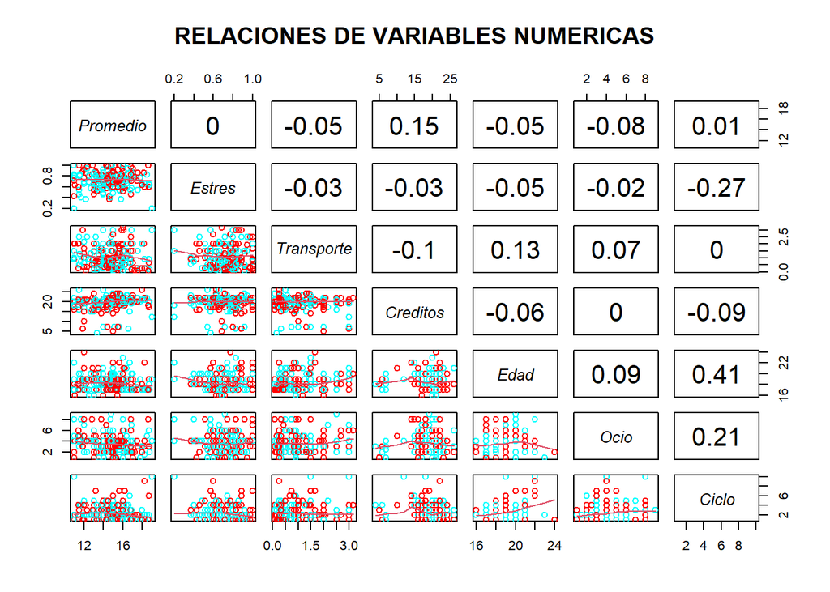

*Conclusión*

### 5.2.2 Objetivo especifico 1:

> Conocer la relación del estrés con el rendimiento académico (si actúa como motivador indirecto o como agente perjudicado) al mismo tiempo en la salud de los alumnos UTEC en el periodo 2022-2.

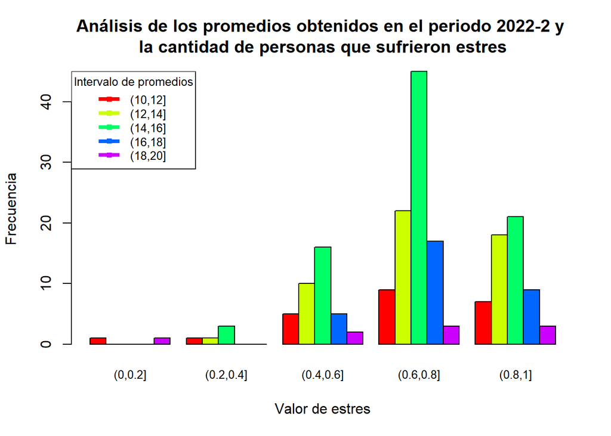

|  | (0,0.2] | (0.2,0.4] | (0.4,0.6] | (0.6,0.8] | (0.8,1] |
| --- | --- | --- | --- | --- | --- |
| (10,12] | 1 | 1 | 5 | 9 | 7 |
| (12,14] | 0 | 1 | 10 | 22 | 18 |
| (14,16] | 0 | 3 | 16 | 45 | 21 |
| (16,18] | 0 | 0 | 5 | 17 | 9 |
| (18,20] | 1 | 0 | 2 | 3 | 3 |

*Mediante la gráfica de correlaciones mostrados anteriormente podemos notar que no existe una correlación entre las variables VALOR DE ESTRÉS con el PROMEDIO ya que el valor de correlación es 0, lo que significa que no existe una relación lineal entre las variables es por ello que concluimos que las variables son totalmente independiente, asimismo dando como respuesta que no actúa como agente motivador o perjudicador, por motivo por el cual investigamos las frecuencias de las variables para poder obtener alguna conclusión extras de las promedios de los alumnos UTEC y el estrés en los mismos en el período 2022-2, concluyendo que los promedios del período 2022-2 se encuentran en mayor frecuencias entre los valores de 14 a 16 de notas en las diferentes escalas de estrés a excepción del mínimo valor de estrés <0;0.2] en los alumnos de UTEC.*

### 5.2.3 Objetivo especifico 2:

> Conocer la importancia del ocio en espacios de educación superior con el fin de reducir el estrés académico en los estudiantes UTEC en el periodo 2022-2.

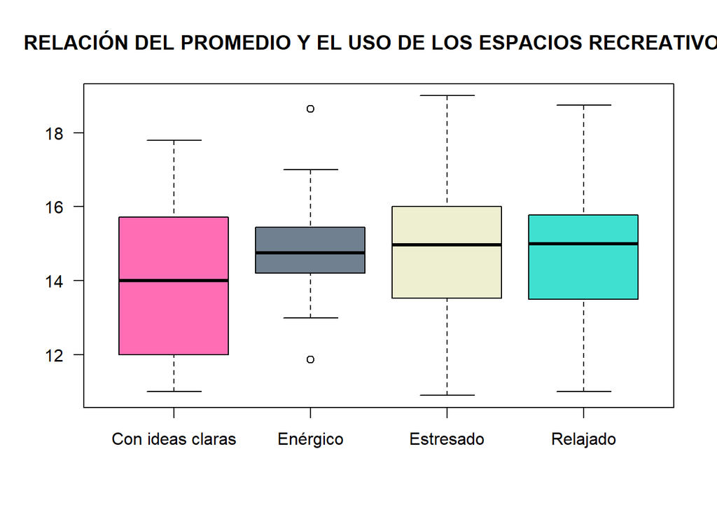

| Fin del usos de los espacios recreativos | frecuencia | Promedio final |
| --- | --- | --- |
| Con ideas claras para mis proyectos | 28 | 13.99 |
| Enérgico capaz de todo | 11 | 14.91 |
| Estresado porque pude haber avanzado proyectos | 80 | 14.82 |
| Feliz y relajado | 80 | 14.72 |

### 5.2.4 Objetivo especifico 3:

**Conocer qué carreras universitarias son las más difíciles según los alumnos de UTEC y la relación que existe con el estrés registrado en sus estudiantes durante el periodo 2022-2.**

Se emplearán las siguientes variables:

*1) La carrera universitaria.*  
*2) El Promedio ponderado de los estudiantes.*  
*3) El valor del estrés de los estudiantes.*  
**– Estas variables en función los estudiantes UTEC durante el periodo 2022-2 –**

Para ello, se calcula el promedio del valor del estrés y promedio ponderado de cada carrera universitaria, se analizan los datos y se determinará si existe o no una relación entre ambas.

**Media del promedio ponderado por carrera**

| Carrera | Media_Promedio_pond |
| --- | --- |
| Ciencia de Datos | 13.75750 |
| Ing de la Energia | 13.77400 |
| Ing Ambiental | 14.15739 |
| Ing Mecanica | 14.33500 |
| Ing Mecatronica | 14.49179 |
| Ing Quimica | 14.60429 |
| Ciencias de la Computacion | 14.79937 |
| Ing Industrial | 14.83391 |
| Bioingenieria | 14.86471 |
| Ing Civil | 14.97958 |
| Ing Electronica | 15.20750 |
| Administración y Negocios Digitales | 15.46250 |

**Media del valor del estrés por carrera**

| Carrera | Media_Valor_estrés |
| --- | --- |
| Ciencias de la Computacion | 0.7910714 |
| Ing Mecatronica | 0.7571429 |
| Ing Industrial | 0.7385093 |
| Bioingenieria | 0.7327731 |
| Ing Quimica | 0.7285714 |
| Ing Civil | 0.7214286 |
| Ing Electronica | 0.7214286 |
| Ing Ambiental | 0.7068323 |
| Ing Mecanica | 0.6914286 |
| Ciencia de Datos | 0.6857143 |
| Administración y Negocios Digitales | 0.6214286 |
| Ing de la Energia | 0.5314286 |

**Relación entre las variables**

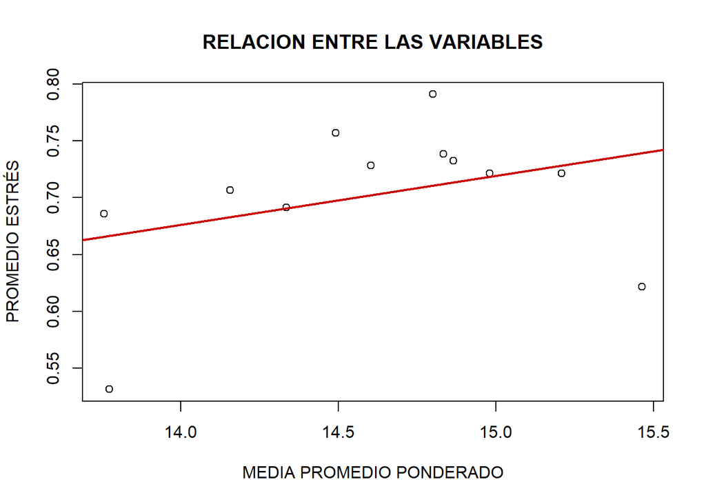

**CONCLUSIONES:** *Se concluye que las 5 carreras universitarias en UTEC con mayor grado de dificultad son (A menor media de promedio ponderado mayor dificultad):*

*- Ciencia de datos*  
*- Ingeniería de la Energía*  
*- Ingeniería Ambiental*  
*- Ingeniería Mecánica*  
*- Ingeniería Mecatrónica*

*Se concluye que existe una ligera relación las variables, donde el estrés generado en los estudiantes es directamente proporcional a la media del promedio ponderado en la carrera universitaria. Es necesario analizar si existe causalidad en el resultado.*

### 5.2.5 Objetivo especifico 4:

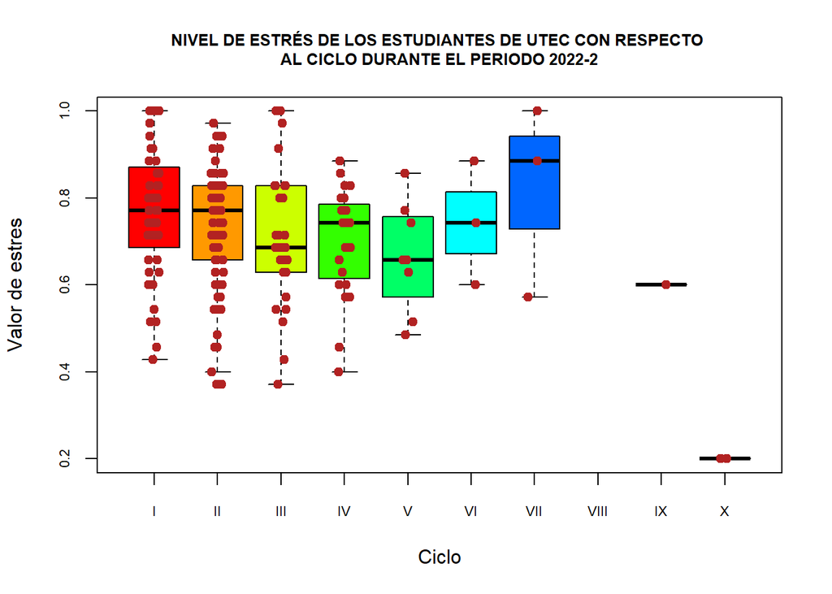

Mediante la gráfica de correlaciones podemos notar que existe una correlación entre las variables *VALOR DE ESTRÉS* con el *CICLO* ya que el valor de correlación es de -0.27, lo que significa que tiene una relación inversa baja o contraria entre ellas. En otras palabras, a medida que el valor de una variable aumenta, el valor de la otra variable tiende a disminuir y viceversa.

Podemos notar que en el ciclo II hay existencia de datos atípicos, podemos analizar esos datos atípicos por una posible relación presente en esos dos datos atípicos que extraemos de la gráfica boxplot realizado en la parte superior.

| Carrera | Ciclo | Promedio | Ocio | Transporte | Creditos | Tiempo_libre | Asesorias | Horas_asesorias | Satisfaccion_asesorias | Valor_estres |
| --- | --- | --- | --- | --- | --- | --- | --- | --- | --- | --- |
| Ing Mecatronica | II Ciclo | 12.18 | 4 | 1.000 | 19 | 5 | Si | 0 | Frustrado, pude hacerlo mejor | 0.3714286 |
| Administración y Negocios Digitales | II Ciclo | 15.80 | 4 | 0.583 | 23 | 2 | Si | 4 | Descontento, no consegui resultados | 0.3714286 |

Comparando los datos obtenidos obtenidos por la tabla encontramos algunas igualdades pero no podemos generalizar los resultados por lo cual determinamos que la variable “valor de estrés” y la variable “ciclo” tienen una relación inversa baja.

*CONCLUSIÓN:* *Para poder lograr obtener una conclusión debimos haber creado la gráfica de VALOR DE ESTRÉS con el CICLO presenta una correlación inversa baja entre estas dos variables. Es importante tener en cuenta que una correlación negativa no implica causalidad, es decir, no podemos afirmar que una variable causa directamente la otra sólo en función de una correlación negativa. Para establecer relaciones causales se requiere de un análisis más profundo y el considerar otros factores.*